# Project 1 of Reproducible Coureses

Ri Feng

5/28/2017

This file is for the [Course Project](https://github.com/rdpeng/RepData_PeerAssessment1). Before doing the project requests, we should import data first.

```r
    dat = read.csv('data/activity.csv')
```

### Histogram of the total number of steps taken each day

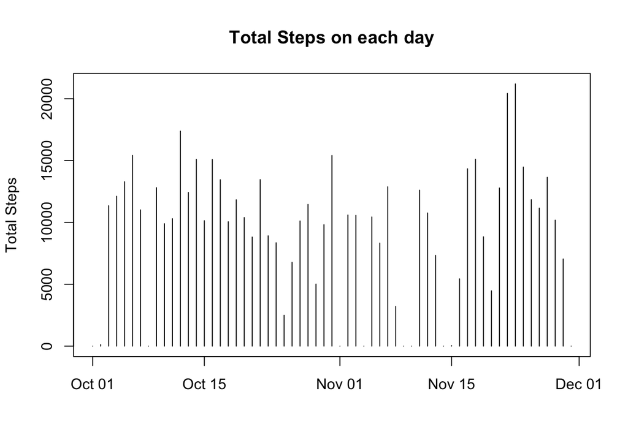

```r
dat.1 = with(dat,tapply(steps,date,sum,na.rm=T))
plot(x=as.Date(names(dat.1)),y=dat.1,type = 'h',
     xlab = "", ylab = "Total Steps",
     main = "Total Steps on each day")
```

### Mean and median number of steps taken each day

```r
dat.2 = aggregate(steps~date,data = dat,
                  FUN = function(x) c(mean=mean(x),median=median(x)))
head(dat.2)
```

```
##         date steps.mean steps.median
## 1 2012-10-02    0.43750      0.00000
## 2 2012-10-03   39.41667      0.00000
## 3 2012-10-04   42.06944      0.00000
## 4 2012-10-05   46.15972      0.00000
## 5 2012-10-06   53.54167      0.00000
## 6 2012-10-07   38.24653      0.00000
```

### Time series plot of the average number of steps taken

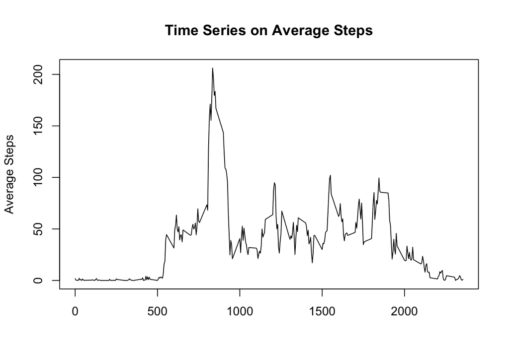

```r
dat.ts = aggregate(steps~interval,data = dat,FUN = mean)
plot(x = dat.ts$interval,y = dat.ts$steps,type = 'l',
    xlab = '', ylab = 'Average Steps',
    main = 'Time Series on Average Steps')
```

### The 5-minute interval that, on average, contains the maximum number of steps

```r
dat.ts[dat.ts$steps==max(dat.ts$steps),]
```

```
##     interval    steps
## 104      835 206.1698
```

It seems *interval 835* contain the maxium value.

### Code to describe and show a strategy for imputing missing data

To deal with the missing value, we can caculate the percentage of missing value of each group (here we group dataset by date). If the percentage is less than 5%, then we just leave out the NAs; if the percentage is greater than 5%, we skip the group and wait for further data collection.

```r
no.na = sum(complete.cases(dat)==FALSE)
```

Total number of rows with missing value is 2304.

```r
pofna = function(x) {sum(is.na(x))/length(x)}
temp = aggregate(steps~date,data = dat,FUN = pofna,na.action = na.pass)
colnames(temp)[2] = 'percent'
library(reshape2)
dat.3 = merge(dat,temp,by = 'date')
dat.3 = dat.3[complete.cases(dat.3) & dat.3$percent<0.05,-4]
head(dat.3)
```

```
##           date steps interval
## 289 2012-10-02     0        0
## 290 2012-10-02     0        5
## 291 2012-10-02     0       10
## 292 2012-10-02     0       15
## 293 2012-10-02     0       20
## 294 2012-10-02     0       25
```

*pofna* is the function to calculate NA percent of each variable. *na.action = na.pass* in *aggregate* function used to keep the NA value, otherwise the default will omit NAs.

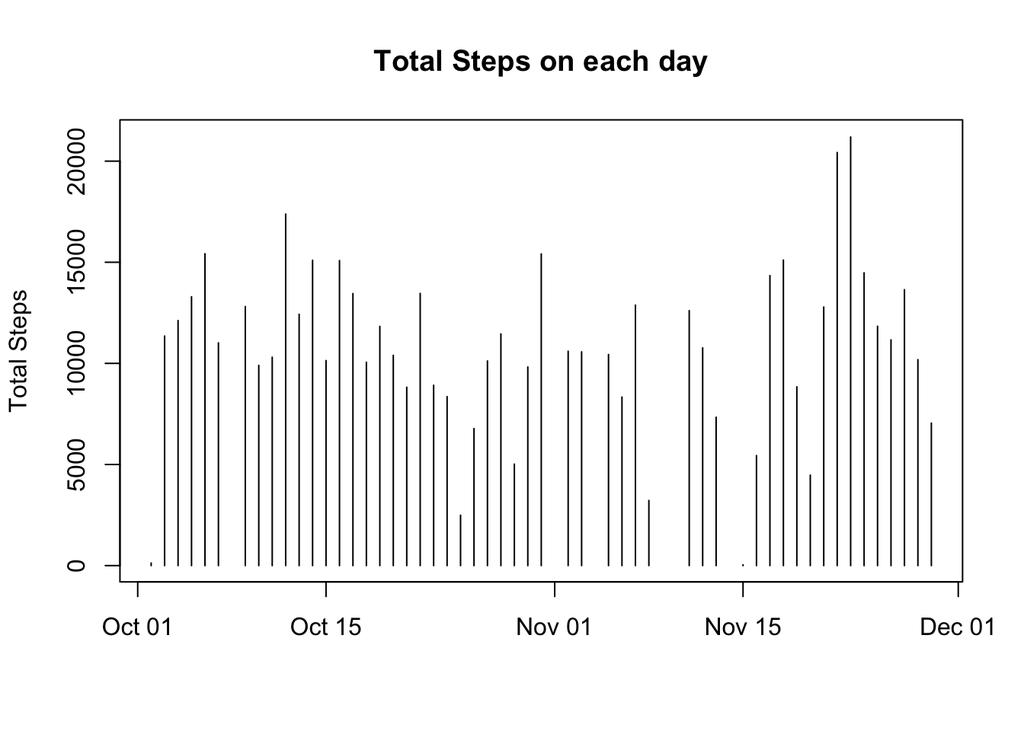

```r
dat.4 = aggregate(steps~date,data = dat.3,FUN = sum)
plot(x = as.Date(dat.4$date),y = dat.4$steps, type = 'h',
     xlab = '',ylab = 'Total Steps',
     main = 'Total Steps on each day')
```

### Panel plot comparing the average number of steps taken per 5-minute interval across weekdays and weekends

First, I split weekdays and weekends data from the original one.

```r
library(lubridate)
weekday = wday(as.Date(dat$date),label = T)
temp = cbind(dat,weekday)
weekends = subset(temp,temp$weekday %in% c('Sat','Sun'))
weekdays = subset(temp,!(temp$weekday %in% c('Sat','Sun')))
```

For each individual dataset, caculate the average steps on each interval.

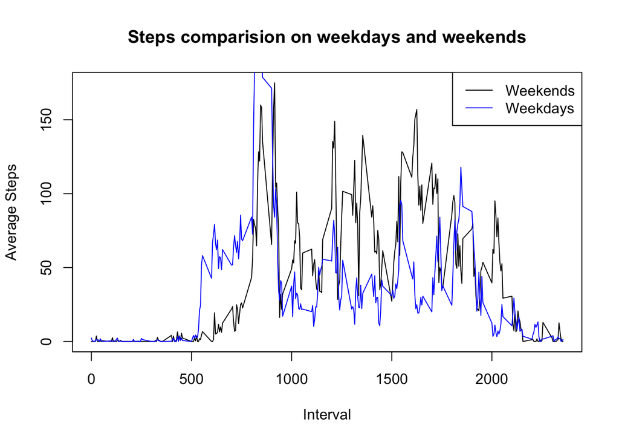

```r
dat.weekends = aggregate(steps~interval,data = weekends,FUN = mean)
dat.weekdays = aggregate(steps~interval,data = weekdays,FUN = mean)
with(dat.weekends,plot(interval,steps,type='l',
                       xlab = 'Interval', ylab = 'Average Steps',
                       main = 'Steps comparision on weekdays and weekends',
                       col = 'black'))
with(dat.weekdays,lines(interval,steps,col='blue'))
legend('topright',c('Weekends','Weekdays'),col = c('black','blue'),lty = c(1,1),)
```